# 市场观察

2017/04/26

## A、指数估值

### (a1)动态市盈率、市净率

核心指数成分股近18个月的动态市盈率及动态市净率中位数走势如下图所示：

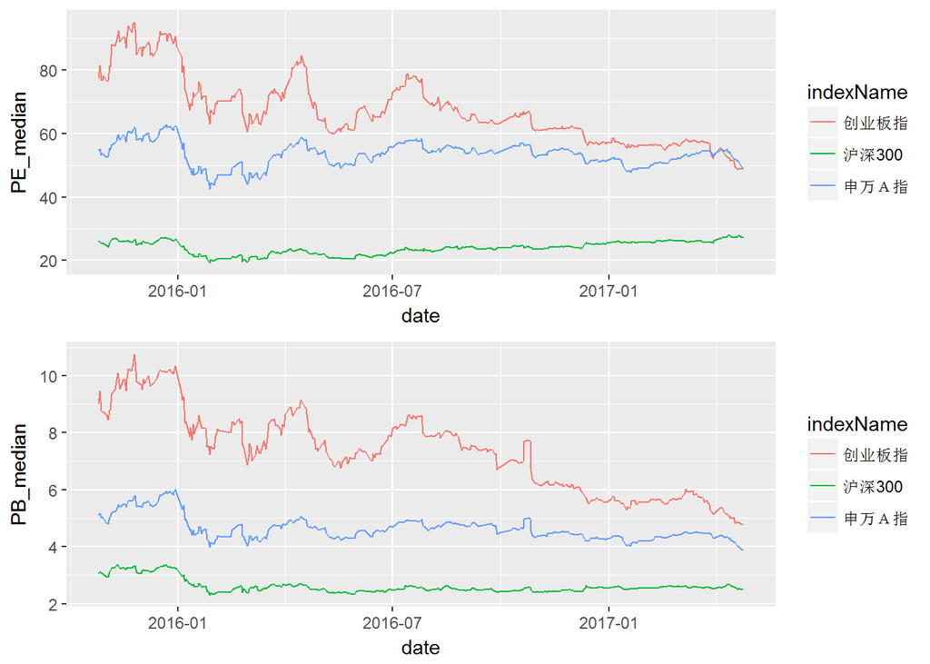

### (a2)动态市盈率、市净率百分位

核心指数近18个月的动态市盈率百分位及动态市净率百分位走势如下图所示：

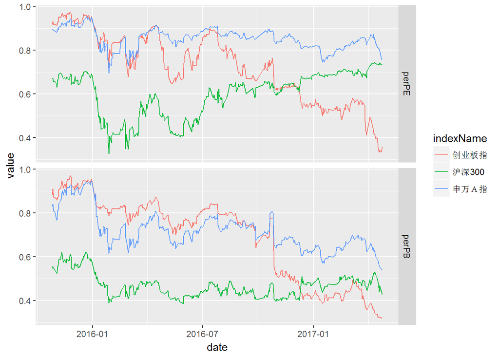

### (a3)指数估值概览

| 指数代码 | 指数简称 | 日期 | 动态市盈率 | 市盈率百分位 | 动态市净率 | 市净率百分位 |
| --- | --- | --- | --- | --- | --- | --- |
| EI000819 | 有色金属 | 2017-04-25 | 64.3 | 88% | 3.4 | 58% |
| EI801003 | 申万Ａ指 | 2017-04-25 | 49.1 | 76% | 3.9 | 54% |
| EI000979 | 大宗商品 | 2017-04-25 | 39.8 | 74% | 2.6 | 53% |
| EI399330 | 深证100 | 2017-04-25 | 33.0 | 68% | 3.8 | 53% |
| EI399959 | 军工指数 | 2017-04-25 | 84.0 | 59% | 5.0 | 57% |
| EI000300 | 沪深300 | 2017-04-25 | 27.5 | 74% | 2.5 | 43% |
| EI399005 | 中小板指P | 2017-04-25 | 39.5 | 58% | 4.5 | 38% |
| EI000905 | 中证500 | 2017-04-25 | 38.0 | 54% | 3.0 | 34% |
| EI000827 | 中证环保 | 2017-04-25 | 41.7 | 64% | 3.0 | 23% |
| EI000934 | 中证金融 | 2017-04-25 | 19.5 | 66% | 1.8 | 17% |
| EI000016 | 上证50 | 2017-04-25 | 18.3 | 64% | 1.6 | 16% |
| EI000998 | 中证TMT | 2017-04-25 | 43.1 | 45% | 3.9 | 32% |
| EI399006 | 创业板指 | 2017-04-25 | 49.3 | 36% | 4.8 | 32% |
| EI000922 | 中证红利 | 2017-04-25 | 16.4 | 40% | 1.7 | 25% |
| EI000933 | 中证医药 | 2017-04-25 | 36.1 | 40% | 3.8 | 4% |
| EI000932 | 中证消费 | 2017-04-25 | 28.5 | 20% | 3.5 | 7% |

### (a4)另类估值

我国10年期国债收益率、金银比价、金油比价，2000年以来的历史百分位如下图所示：

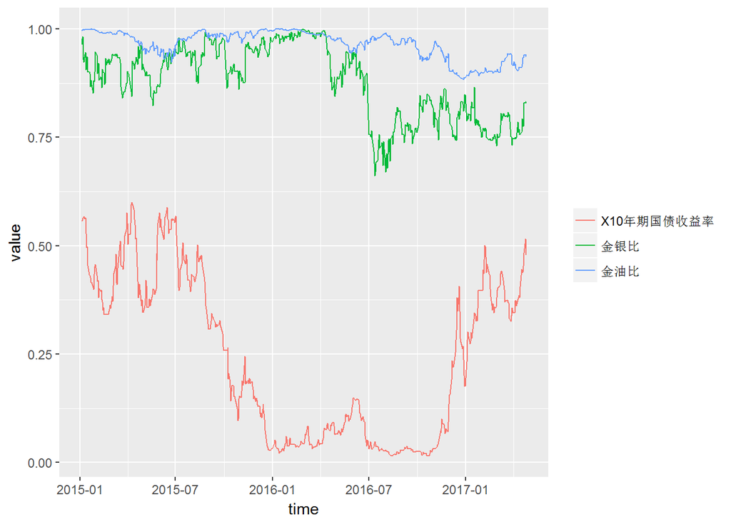

## B、基差

### (b1)基差走势

三大股指期货合约基差走势如下图，其中当月合约和次月合约年化基差百分比波动较大，仅展示合约基差百分比，当季合约和次季合约展示基差年化百分比：

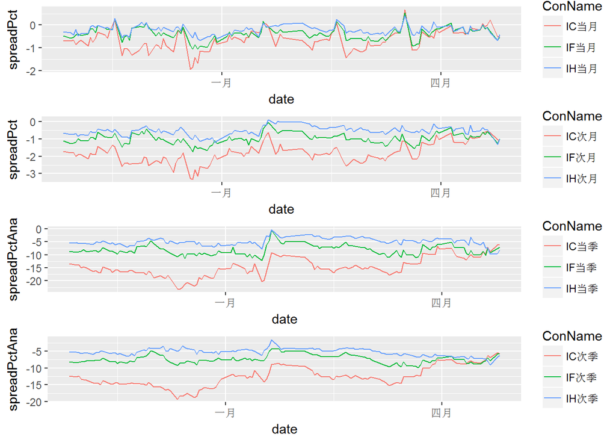

### (b2)基差概况

三大股指期货连续合约基差概况如下表，近月合约临近到期日，年化基差百分比数据波动较大：

| 日期 | 合约代码 | 合约收盘价 | 指数收盘价 | 基差 | 基差百分比 | 年化基差百分比 |
| --- | --- | --- | --- | --- | --- | --- |
| 2017-04-25 | IC1705 | 6128.0 | 6160.5 | -32.5 | -0.5% | -8.3% |
| 2017-04-25 | IC1706 | 6093.6 | 6160.5 | -66.9 | -1.1% | -7.9% |
| 2017-04-25 | IC1709 | 6013.4 | 6160.5 | -147.1 | -2.4% | -6.2% |
| 2017-04-25 | IC1712 | 5933.4 | 6160.5 | -227.1 | -3.7% | -5.8% |
| 2017-04-25 | IF1705 | 3422.6 | 3441.0 | -18.4 | -0.5% | -8.4% |
| 2017-04-25 | IF1706 | 3407.0 | 3441.0 | -34.0 | -1.0% | -7.1% |
| 2017-04-25 | IF1709 | 3346.6 | 3441.0 | -94.4 | -2.7% | -7.2% |
| 2017-04-25 | IF1712 | 3316.4 | 3441.0 | -124.6 | -3.6% | -5.7% |
| 2017-04-25 | IH1705 | 2334.8 | 2344.7 | -9.9 | -0.4% | -6.6% |
| 2017-04-25 | IH1706 | 2321.0 | 2344.7 | -23.7 | -1.0% | -7.3% |
| 2017-04-25 | IH1709 | 2271.0 | 2344.7 | -73.7 | -3.1% | -8.2% |
| 2017-04-25 | IH1712 | 2251.8 | 2344.7 | -92.9 | -4.0% | -6.3% |

## C、套利和事件

### (c1)复牌股票套利

近两天复牌股票套利情况如下表：

[1] “No qualified index!”

[1] “No Arbitrage!”

### (c2)定增基金(provided by han.qian)

定增基金数据如下表，明细数据参见钱瀚的模板。

| 代码 | 名称 | 到期日期 | 最新净值 | 昨日收盘价 | 折溢价率 | 整体隐含折价率 | 大盘下跌0.1净值变化 |
| --- | --- | --- | --- | --- | --- | --- | --- |
| 168101.OF | 九泰锐智 | 20200814 | 1.19 | 1.04 | -11.9% | 3.9% | -9.7% |
| 168102.OF | 九泰锐富 | 20210204 | 1.02 | 0.87 | -15.1% | 3.1% | -5.3% |
| 501015.OF | 财通升级 | 20170908 | 1.02 | 0.99 | -2.6% | 1.9% | -8.9% |
| 160518.OF | 博时睿远 | 20171016 | 0.97 | 0.93 | -4.5% | 1.2% | -6.4% |

定增基金近期的净值走势如下图：

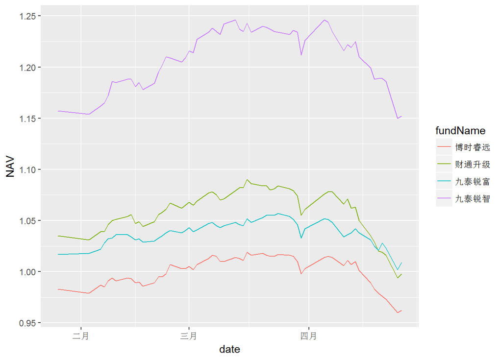

定增基金近期的折溢价率百分比走势如下图：

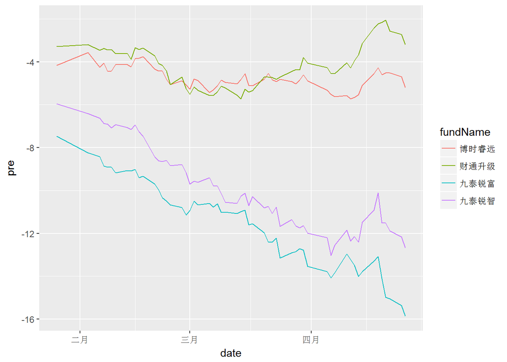

### (c3)定增解禁(provided by han.qian)

近十天定增解禁的股票情况如下表。

| 股票代码 | 股票简称 | 起始跟踪日 | 解禁日 | 解禁百分比 | 区间涨跌幅 | 所属行业指数 | 行业指数涨跌幅 |
| --- | --- | --- | --- | --- | --- | --- | --- |
| EQ002617 | 露笑科技 | 2017-04-11 | 2017-04-25 | 18% | -8.1% | 申万电气设备 | -7.9% |
| EQ000690 | 宝新能源 | 2017-04-12 | 2017-04-26 | 23% | -18.2% | 申万公用事业 | -5.7% |
| EQ000959 | 首钢股份 | 2017-04-14 | 2017-04-28 | 78% | -11.1% | 申万钢铁 | -10.5% |
| EQ002279 | 久其软件 | 2017-04-14 | 2017-04-30 | 5% | -5.0% | 申万计算机 | -5.2% |
| EQ000887 | 中鼎股份 | 2017-04-18 | 2017-05-03 | 9% | -2.8% | 申万汽车 | -3.3% |
| EQ000816 | 智慧农业 | 2017-04-19 | 2017-05-04 | 30% | -8.8% | 申万机械设备 | -4.7% |
| EQ600497 | 驰宏锌锗 | 2017-04-19 | 2017-05-04 | 15% | -5.2% | 申万有色金属 | -6.9% |
| EQ002335 | 科华恒盛 | 2017-04-20 | 2017-05-05 | 14% | -1.7% | 申万电气设备 | -3.8% |
| EQ002607 | 亚夏汽车 | 2017-04-20 | 2017-05-05 | 28% | -1.0% | 申万汽车 | -2.0% |
| EQ002654 | 万润科技 | 2017-04-21 | 2017-05-08 | 7% | -3.9% | 申万电子 | -1.6% |
| EQ002425 | 凯撒文化 | 2017-04-24 | 2017-05-09 | 6% | -6.0% | 申万纺织服装 | -1.8% |
| EQ300266 | 兴源环境 | 2017-04-24 | 2017-05-09 | 8% | 0.0% | 申万机械设备 | -2.8% |
| EQ600565 | 迪马股份 | 2017-04-24 | 2017-05-09 | 59% | 0.1% | 申万房地产 | -1.8% |
| EQ300279 | 和晶科技 | 2017-04-25 | 2017-05-10 | 10% | 0.3% | 申万电子 | 0.8% |
| EQ601222 | 林洋能源 | 2017-04-25 | 2017-05-10 | 22% | 0.6% | 申万电气设备 | 0.3% |
| EQ300433 | 蓝思科技 | 2017-04-26 | 2017-05-11 | 75% | 0.0% | 申万电子 | 0.0% |
| EQ603885 | 吉祥航空 | 2017-04-26 | 2017-05-11 | 69% | 0.0% | 申万交通运输 | 0.0% |

### (c4)中小板业绩预增预测(provided by han.qian)

中小板规定正式财务报告发布的同时需要发布新一期的业绩预报，比如年报中会包含一季报预告的情况。我们假设公司的盈利状况有动量效应，年报预增的公司一季度也会预增，在正式财务报告发布前20个交易日开始埋伏，然后等正式报告发布日卖出。具体研究参见钱瀚前期的研究。需要注意的是这里的收益率仅做展示，仅仅是每日全部入选股票的平均收益率，并没有做成一个事件组合。

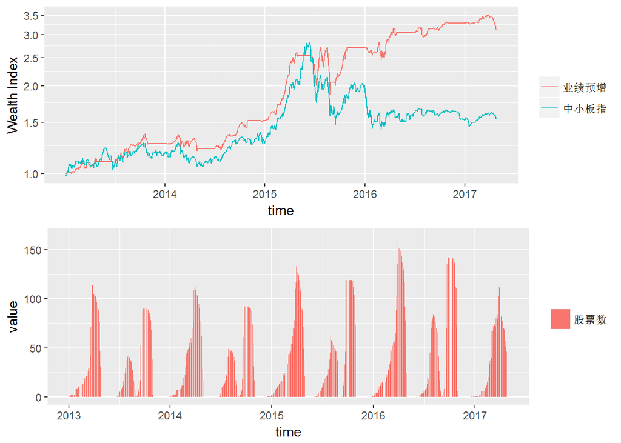

历年收益统计如下表所示。

|  | 业绩预增 | 中小板指 |
| --- | --- | --- |
| 2013-01-04 ~ 2013-12-31 | 26.6% | 17.5% |
| 2014-01-02 ~ 2014-12-31 | 20.1% | 9.7% |
| 2015-01-05 ~ 2015-12-31 | 77.9% | 53.7% |
| 2016-01-04 ~ 2016-12-30 | 22.0% | -22.9% |
| 2017-01-03 ~ 2017-04-25 | -4.5% | 1.9% |
| Cumulative Return | 215.1% | 55.6% |
| Annualized Return | 30.5% | 10.8% |

### (c5)主动量化基金

主动量化基金最近一年和最近一个季度的收益率密度图如下所示。

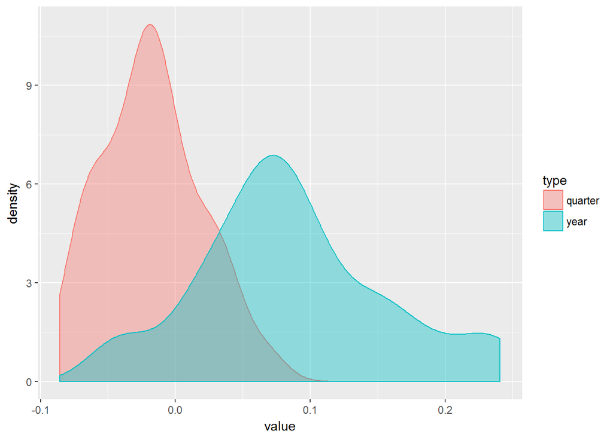

主动量化基金近一年和近一个季度表现最好的20只基金如下表所示。

| 季度排名 | 基金简称 | 成立日 | 总规模 | 季度收益 | 年度排名 | 基金简称 | 成立日 | 总规模 | 年度收益 |
| --- | --- | --- | --- | --- | --- | --- | --- | --- | --- |
| 1 | 景顺长城量化新动力 | 2016-07-13 | 1.2 | 7.0% | 1 | 华泰柏瑞量化优选 | 2014-12-17 | 7.2 | 24.1% |
| 2 | 金信量化精选 | 2016-07-01 | 2.1 | 6.6% | 2 | 华泰柏瑞量化智慧 | 2015-06-03 | 5.3 | 23.2% |
| 3 | 华泰柏瑞量化先行 | 2010-06-22 | 5.6 | 4.5% | 3 | 华泰柏瑞量化先行 | 2010-06-22 | 5.6 | 23.0% |
| 4 | 华泰柏瑞量化智慧 | 2015-06-03 | 5.3 | 4.3% | 4 | 华泰柏瑞量化驱动 | 2015-03-24 | 19.5 | 19.6% |
| 5 | 泰达宏利量化 | 2016-08-30 | 1.9 | 4.2% | 5 | 华泰柏瑞量化A | 2013-08-02 | 46.7 | 18.6% |
| 6 | 长盛量化红利策略 | 2009-11-25 | 2.5 | 3.7% | 6 | 九泰久盛量化先锋 | 2015-11-10 | 4.5 | 16.2% |
| 7 | 华泰柏瑞量化优选 | 2014-12-17 | 7.2 | 3.6% | 7 | 泰达宏利逆向策略 | 2012-05-23 | 16.2 | 15.6% |
| 8 | 华泰柏瑞量化驱动 | 2015-03-24 | 19.5 | 2.9% | 8 | 景顺长城量化精选 | 2015-02-04 | 13.4 | 15.5% |
| 9 | 景顺长城量化精选 | 2015-02-04 | 13.4 | 2.8% | 9 | 泰达宏利同顺大数据A | 2016-02-23 | 2.1 | 14.4% |
| 10 | 华泰柏瑞量化A | 2013-08-02 | 46.7 | 2.7% | 10 | 泰达宏利改革动力A | 2015-02-13 | 18.4 | 13.9% |
| 11 | 华润元大医疗保健量化 | 2014-08-18 | 0.5 | 2.3% | 11 | 华商大盘量化精选 | 2013-04-09 | 12.3 | 12.1% |
| 12 | 东吴安鑫量化 | 2016-06-03 | 2.4 | 2.1% | 12 | 大成核心双动力 | 2010-06-22 | 1.3 | 11.0% |
| 13 | 长盛医疗行业 | 2016-02-03 | 0.6 | 2.1% | 13 | 申万菱信量化小盘 | 2011-06-16 | 30.9 | 10.7% |
| 14 | 华商量化进取 | 2015-04-09 | 26.7 | 1.9% | 14 | 华富量子生命力 | 2011-04-01 | 0.8 | 10.5% |
| 15 | 民生加银量化中国 | 2016-05-19 | 1.4 | 0.9% | 15 | 长信量化多策略 | 2015-07-14 | 3.3 | 9.8% |
| 16 | 华商新量化 | 2014-06-05 | 6.3 | 0.7% | 16 | 汇添富成长多因子量化策略 | 2015-02-16 | 17.4 | 9.4% |
| 17 | 泰达宏利同顺大数据A | 2016-02-23 | 2.1 | 0.5% | 17 | 长盛量化红利策略 | 2009-11-25 | 2.5 | 9.3% |
| 18 | 泰达宏利改革动力A | 2015-02-13 | 18.4 | 0.4% | 18 | 南方量化成长 | 2015-06-29 | 14.2 | 8.7% |
| 19 | 大成动态量化 | 2016-09-20 | 3.1 | 0.4% | 19 | 南方策略优化 | 2010-03-30 | 13.8 | 8.4% |
| 20 | 建信多因子量化 | 2016-08-09 | 1.9 | -0.1% | 20 | 长信量化先锋A | 2010-11-18 | 85.9 | 7.9% |

## D、择时

### (d1)等权指数

从历史来看，A股市场存在小盘股效应，市值小的股票长期整体跑赢大市值的股票，美股市场同样存在类似的现象。而目前大部分指数的编制方案都是类似市值加权，为了抛去市值的影响，下面展示几个等权指数，其中中证500等权和沪深300等权是现有的指数，中证全指等权是自己编制的指数。等权指数可以视为一个更好地业绩比较基准。等权指数走势如下图：

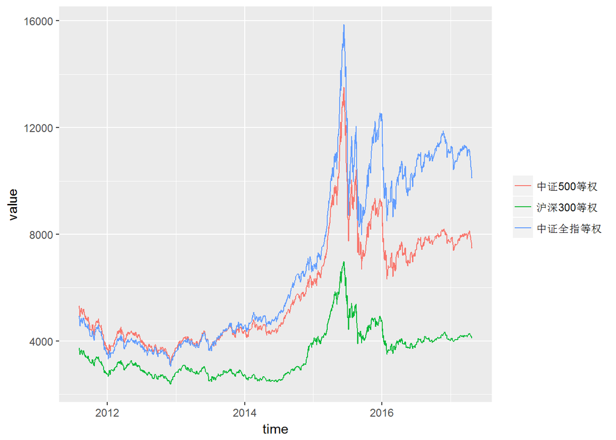

等权指数收益率统计见下表：

|  | 中证500等权 | 沪深300等权 | 中证全指等权 |
| --- | --- | --- | --- |
| 2011-08-02 ~ 2011-12-30 | -29.2% | -25.5% | -27.8% |
| 2012-01-04 ~ 2012-12-31 | -0.0% | 1.5% | 2.2% |
| 2013-01-04 ~ 2013-12-31 | 16.7% | -3.2% | 25.8% |
| 2014-01-02 ~ 2014-12-31 | 40.2% | 43.7% | 46.0% |
| 2015-01-05 ~ 2015-12-31 | 47.6% | 20.1% | 84.4% |
| 2016-01-04 ~ 2016-12-30 | -15.1% | -15.1% | -10.3% |
| 2017-01-03 ~ 2017-04-25 | -2.4% | 2.3% | -8.2% |
| 累计收益率 | 41.6% | 9.9% | 105.8% |
| 年化收益率 | 6.3% | 1.7% | 13.4% |
| 年化波动率 | 28.6% | 25.9% | 29.0% |
| 年化Sharpe值 | 21.8% | 6.4% | 46.2% |
| 最大回撤 | 53.3% | 50.0% | 49.7% |

### (d2)大盘均线强弱指数

大盘均线强弱指数在一定程度上可以视为一个反转指标，当大盘均线得分接近8分时，预示市场接近顶部，当大盘均线得分接近0分时，预示市场接近底部。  
大盘均线强弱指数近一年来走势如下图：

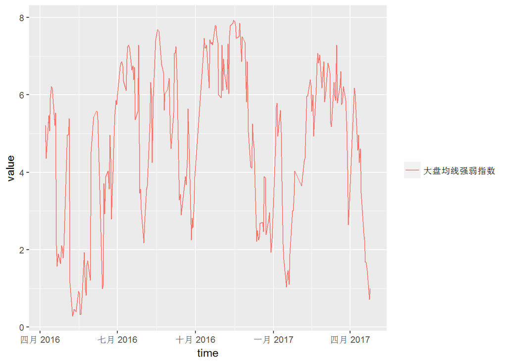

申万一级行业的最新得分见下表：

| 日期 | 指数代码 | 行业 | 最新得分 | 上周得分 |
| --- | --- | --- | --- | --- |
| 2017-04-25 | EI801110 | 家用电器 | 8 | 8 |
| 2017-04-25 | EI801120 | 食品饮料 | 8 | 7 |
| 2017-04-25 | EI801160 | 公用事业 | 3 | 6 |
| 2017-04-25 | EI801710 | 建筑材料 | 3 | 5 |
| 2017-04-25 | EI801170 | 交通运输 | 2 | 5 |
| 2017-04-25 | EI801720 | 建筑装饰 | 2 | 5 |
| 2017-04-25 | EI801040 | 钢铁 | 1 | 2 |
| 2017-04-25 | EI801740 | 国防军工 | 1 | 3 |
| 2017-04-25 | EI801010 | 农林牧渔 | 0 | 0 |
| 2017-04-25 | EI801020 | 采掘 | 0 | 0 |
| 2017-04-25 | EI801030 | 化工 | 0 | 1 |
| 2017-04-25 | EI801050 | 有色金属 | 0 | 0 |
| 2017-04-25 | EI801080 | 电子 | 0 | 0 |
| 2017-04-25 | EI801130 | 纺织服装 | 0 | 0 |
| 2017-04-25 | EI801140 | 轻工制造 | 0 | 0 |
| 2017-04-25 | EI801150 | 医药生物 | 0 | 0 |
| 2017-04-25 | EI801180 | 房地产 | 0 | 3 |
| 2017-04-25 | EI801200 | 商业贸易 | 0 | 0 |
| 2017-04-25 | EI801210 | 休闲服务 | 0 | 0 |
| 2017-04-25 | EI801230 | 综合 | 0 | 0 |
| 2017-04-25 | EI801730 | 电气设备 | 0 | 0 |
| 2017-04-25 | EI801750 | 计算机 | 0 | 0 |
| 2017-04-25 | EI801760 | 传媒 | 0 | 0 |
| 2017-04-25 | EI801770 | 通信 | 0 | 0 |
| 2017-04-25 | EI801780 | 银行 | 0 | 0 |
| 2017-04-25 | EI801790 | 非银金融 | 0 | 0 |
| 2017-04-25 | EI801880 | 汽车 | 0 | 1 |
| 2017-04-25 | EI801890 | 机械设备 | 0 | 1 |

### (d3)LLT及均线择时

LLT本质上是一个改进的单均线择时指标，较原始的均线择时延迟更低。  
择时模型和指数本身的净值走势如下图：

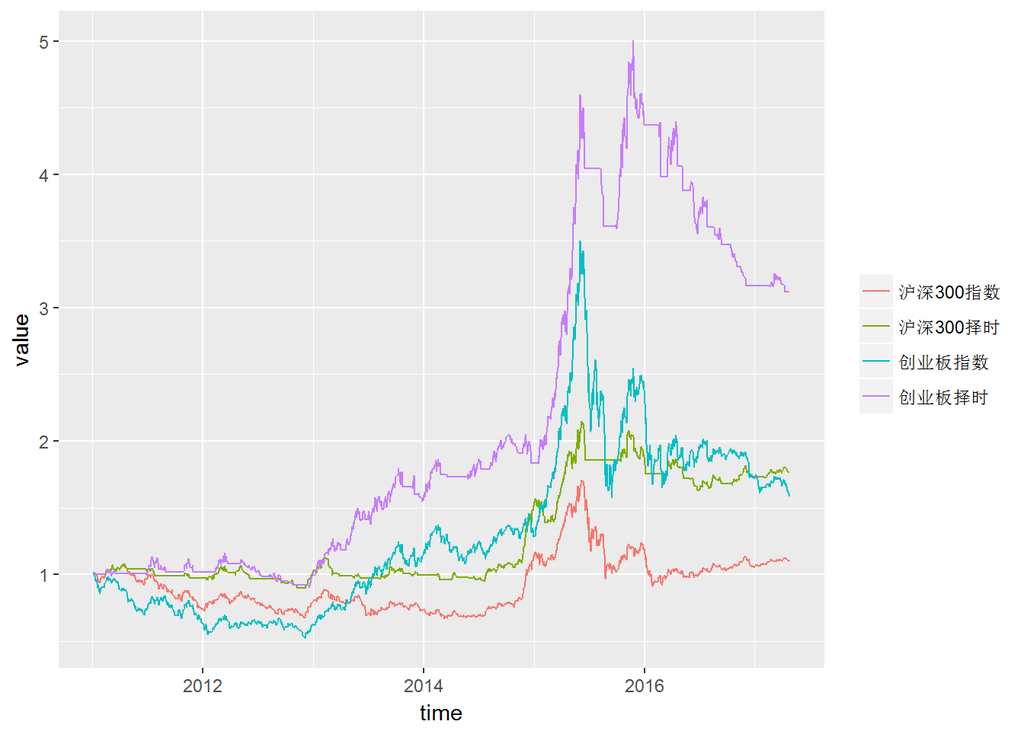

择时模型和指数的收益率统计如下表：

|  | 沪深300指 | 沪深300LLT | 创业板指 | 创业板MA |
| --- | --- | --- | --- | --- |
| 2011-01-04 ~ 2011-12-30 | -25.0% | -2.5% | -35.9% | 1.9% |
| 2012-01-04 ~ 2012-12-31 | 7.6% | 5.4% | -2.1% | -1.7% |
| 2013-01-04 ~ 2013-12-31 | -7.6% | -3.2% | 82.7% | 55.7% |
| 2014-01-02 ~ 2014-12-31 | 51.7% | 52.4% | 12.8% | 17.7% |
| 2015-01-05 ~ 2015-12-31 | 5.6% | 24.3% | 84.4% | 138.1% |
| 2016-01-04 ~ 2016-12-30 | -11.3% | -8.1% | -27.7% | -27.5% |
| 2017-01-03 ~ 2017-04-25 | 4.0% | 1.9% | -7.3% | -1.6% |
| 累计收益率 | 10.0% | 76.7% | 59.9% | 211.7% |
| 年化收益率 | 1.5% | 9.4% | 7.7% | 19.7% |
| 年化波动率 | 24.0% | 15.4% | 32.7% | 22.0% |
| 年化Sharpe值 | 6.3% | 61.3% | 23.6% | 89.7% |
| 最大回撤 | 46.7% | 24.0% | 54.9% | 37.7% |

择时模型最近10个交易日的信号如下表：

| 日期 | 沪深300收盘价 | 沪深300LLT | 沪深300择时信号 | 创业板收盘价 | 创业板MA30 | 创业板择时信号 |
| --- | --- | --- | --- | --- | --- | --- |
| 2017-04-12 | 3509.439 | 3486.360 | hold | 1897.507 | 1942.675 |  |
| 2017-04-13 | 3514.566 | 3489.467 | hold | 1910.476 | 1942.119 |  |
| 2017-04-14 | 3486.505 | 3491.653 | hold | 1887.460 | 1940.636 |  |
| 2017-04-17 | 3479.942 | 3492.580 | hold | 1868.281 | 1938.898 |  |
| 2017-04-18 | 3462.743 | 3492.666 | hold | 1848.203 | 1936.229 |  |
| 2017-04-19 | 3445.876 | 3491.615 | sell | 1845.382 | 1932.316 |  |
| 2017-04-20 | 3461.548 | 3490.553 |  | 1850.390 | 1928.067 |  |
| 2017-04-21 | 3466.787 | 3490.200 |  | 1839.006 | 1923.880 |  |
| 2017-04-24 | 3431.259 | 3488.856 |  | 1809.911 | 1919.078 |  |
| 2017-04-25 | 3440.974 | 3486.717 |  | 1818.870 | 1914.707 |  |

### (d4)网格交易

在经历了三轮股灾，A股逐步回归正常，在过去的一段时间呈现一个震荡的格局，如果未来没有增量信息，很可能维持震荡。结合股指期货的贴水，前期研究了一下网格交易。网格交易的结果如下图：

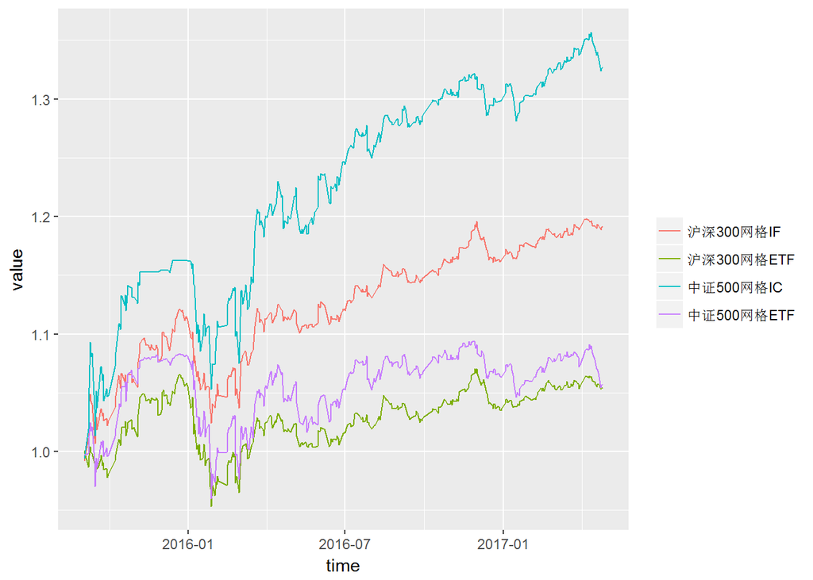

网格交易的收益统计如下表：

|  | 沪深300指数 | 沪深300网格IF | 沪深300网格ETF | 中证500指数 | 中证500网格IC | 中证500网格ETF |
| --- | --- | --- | --- | --- | --- | --- |
| 2015-09-02 ~ 2015-12-31 | 11.0% | 11.1% | 5.6% | 23.5% | 16.2% | 8.1% |
| 2016-01-04 ~ 2016-12-30 | -11.3% | 4.7% | -1.8% | -17.8% | 11.8% | -1.6% |
| 2017-01-03 ~ 2017-04-26 | 4.1% | 2.4% | 1.7% | -1.4% | 2.1% | -0.6% |
| 累计收益率 | 2.5% | 19.2% | 5.5% | 0.1% | 32.7% | 5.7% |
| 年化收益率 | 1.5% | 11.2% | 3.3% | 0.1% | 18.7% | 3.4% |
| 年化波动率 | 21.4% | 9.0% | 8.8% | 29.0% | 13.2% | 11.3% |
| 年化Sharpe值 | 6.9% | 124.6% | 37.4% | 0.2% | 141.2% | 30.4% |
| 最大回撤 | 26.4% | 8.6% | 10.5% | 33.5% | 9.4% | 11.4% |

## E、选股

### (e1)超级小盘股

作为多因子选股的第一部分，有必要从市值因子说起。 下面利用总市值因子，在中证全指的成分股内，选出市值最小的100只股票，这里剔除了ST、新上市、停牌和涨停的股票，100只股票等权配置，每月换仓一次，交易成本千分之三。超级小盘股策略的净值表现如下图。

[output not shown]

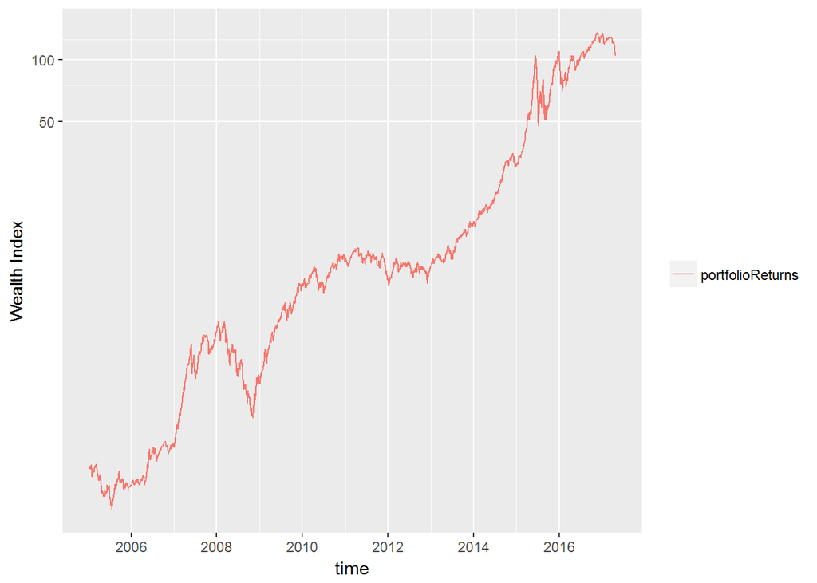

超级小盘股的收益统计如下表：

|  | 超级小盘股 | 沪深300 | 中证500 |
| --- | --- | --- | --- |
| 2005-01-05 ~ 2005-12-30 | -16.7% | -6.0% | -12.8% |
| 2006-01-04 ~ 2006-12-29 | 55.8% | 121.0% | 100.7% |
| 2007-01-04 ~ 2007-12-28 | 265.1% | 161.5% | 186.6% |
| 2008-01-02 ~ 2008-12-31 | -44.5% | -65.9% | -60.8% |
| 2009-01-05 ~ 2009-12-31 | 205.8% | 96.7% | 131.3% |
| 2010-01-04 ~ 2010-12-31 | 32.2% | -12.5% | 10.5% |
| 2011-01-04 ~ 2011-12-30 | -19.4% | -25.0% | -33.8% |
| 2012-01-04 ~ 2012-12-31 | 15.3% | 7.6% | 0.3% |
| 2013-01-04 ~ 2013-12-31 | 63.3% | -7.6% | 16.9% |
| 2014-01-02 ~ 2014-12-31 | 88.8% | 51.7% | 39.0% |
| 2015-01-05 ~ 2015-12-31 | 254.4% | 5.6% | 43.1% |
| 2016-01-04 ~ 2016-12-30 | 21.2% | -11.3% | -17.8% |
| 2017-01-03 ~ 2017-04-25 | -19.3% | 4.0% | -1.6% |
| 累计收益率 | 10451.6% | 250.1% | 526.3% |
| 年化收益率 | 46.1% | 10.7% | 16.1% |
| 年化波动率 | 35.7% | 28.3% | 32.4% |
| 年化Sharpe值 | 128.9% | 37.8% | 49.6% |
| 最大回撤 | 66.3% | 72.3% | 72.4% |

### (e2)银行股轮动

银行股轮动是参考集思录的热门贴银行股评级而来的，数据的提取和参数的设置和原贴有一定的差别，所以轮动的效果也会不太一样，不过回测的效果还不错，从现在开始跟踪。2013年以来银行股轮动的结果如下图：

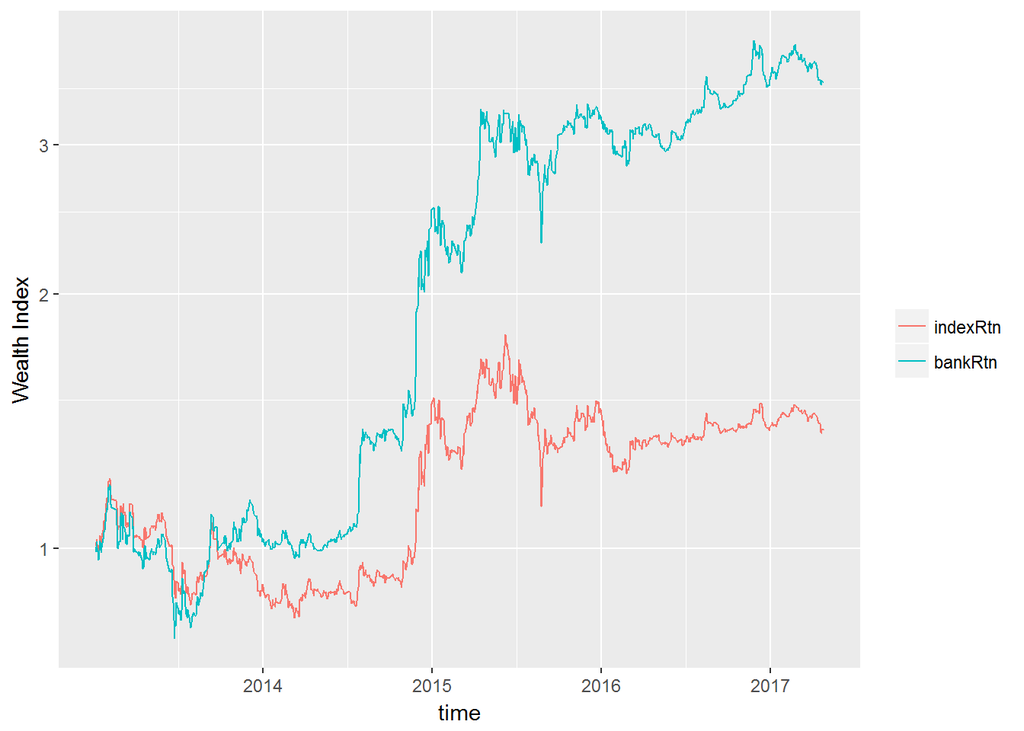

银行股轮动的收益统计如下表：

|  | 申万银行 | 银行股轮动 |
| --- | --- | --- |
| 2013-01-04 ~ 2013-12-31 | -9.2% | 3.0% |
| 2014-01-02 ~ 2014-12-31 | 63.2% | 144.5% |
| 2015-01-05 ~ 2015-12-31 | -1.4% | 29.0% |
| 2016-01-04 ~ 2016-12-30 | -4.9% | 10.5% |
| 2017-01-03 ~ 2017-04-25 | -0.3% | -0.8% |
| 累计收益率 | 38.6% | 256.0% |
| 年化收益率 | 7.9% | 34.3% |
| 年化波动率 | 28.0% | 31.9% |
| 年化Sharpe值 | 28.1% | 107.3% |
| 最大回撤 | 37.4% | 34.2% |

银行股轮动的最新得分如下表：

| 日期 | 代码 | 简称 | PB | 预期ROE | 翻倍期 | 持仓 |
| --- | --- | --- | --- | --- | --- | --- |
| 2017-04-25 | EQ600015 | 华夏银行 | 0.78 | 0.15 | 3.2 | hold |
| 2017-04-25 | EQ601818 | 光大银行 | 0.73 | 0.11 | 3.5 |  |
| 2017-04-25 | EQ601328 | 交通银行 | 0.71 | 0.10 | 3.6 |  |
| 2017-04-25 | EQ601988 | 中国银行 | 0.74 | 0.11 | 3.7 |  |
| 2017-04-25 | EQ000001 | 平安银行 | 0.74 | 0.11 | 3.9 |  |
| 2017-04-25 | EQ601288 | 农业银行 | 0.82 | 0.13 | 4.0 |  |
| 2017-04-25 | EQ600016 | 民生银行 | 0.83 | 0.13 | 4.2 |  |
| 2017-04-25 | EQ600000 | 浦发银行 | 0.88 | 0.14 | 4.5 |  |
| 2017-04-25 | EQ601398 | 工商银行 | 0.87 | 0.13 | 4.5 |  |
| 2017-04-25 | EQ601166 | 兴业银行 | 0.93 | 0.14 | 4.6 |  |
| 2017-04-25 | EQ601998 | 中信银行 | 0.80 | 0.11 | 4.7 |  |
| 2017-04-25 | EQ601939 | 建设银行 | 0.94 | 0.14 | 4.9 |  |
| 2017-04-25 | EQ601169 | 北京银行 | 1.02 | 0.13 | 5.8 |  |
| 2017-04-25 | EQ601009 | 南京银行 | 1.09 | 0.14 | 6.1 |  |
| 2017-04-25 | EQ600036 | 招商银行 | 1.19 | 0.15 | 6.2 |  |
| 2017-04-25 | EQ002142 | 宁波银行 | 1.35 | 0.16 | 6.6 |  |
| 2017-04-25 | EQ601229 | 上海银行 | 1.19 | 0.12 | 7.5 |  |
| 2017-04-25 | EQ600919 | 江苏银行 | 1.29 | 0.13 | 7.9 |  |
| 2017-04-25 | EQ601997 | 贵阳银行 | 1.74 | 0.17 | 8.0 |  |
| 2017-04-25 | EQ600926 | 杭州银行 | 1.45 | 0.11 | 10.2 |  |
| 2017-04-25 | EQ601128 | 常熟银行 | 2.83 | 0.10 | 17.5 |  |
| 2017-04-25 | EQ600908 | 无锡银行 | 3.96 | 0.10 | 21.7 |  |
| 2017-04-25 | EQ603323 | 吴江银行 | 2.84 | 0.08 | 22.4 |  |
| 2017-04-25 | EQ002807 | 江阴银行 | 4.14 | 0.09 | 25.9 |  |

## F、多因子跟踪

### (f1)近一个月周频因子IC

全市场因子IC表现如下图所示，根据因子IC均值大于0，胜率大于50%简单区分了一下alpha因子和风险因子。

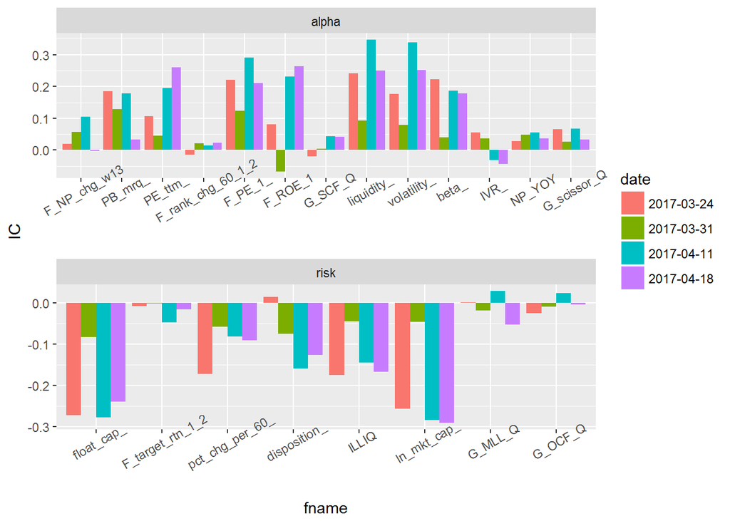

沪深300因子IC表现如下图所示。

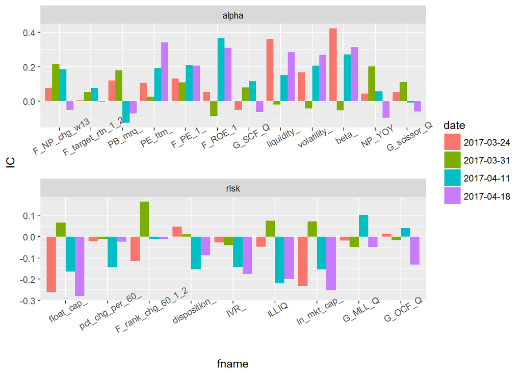

中证500因子IC表现如下图所示。

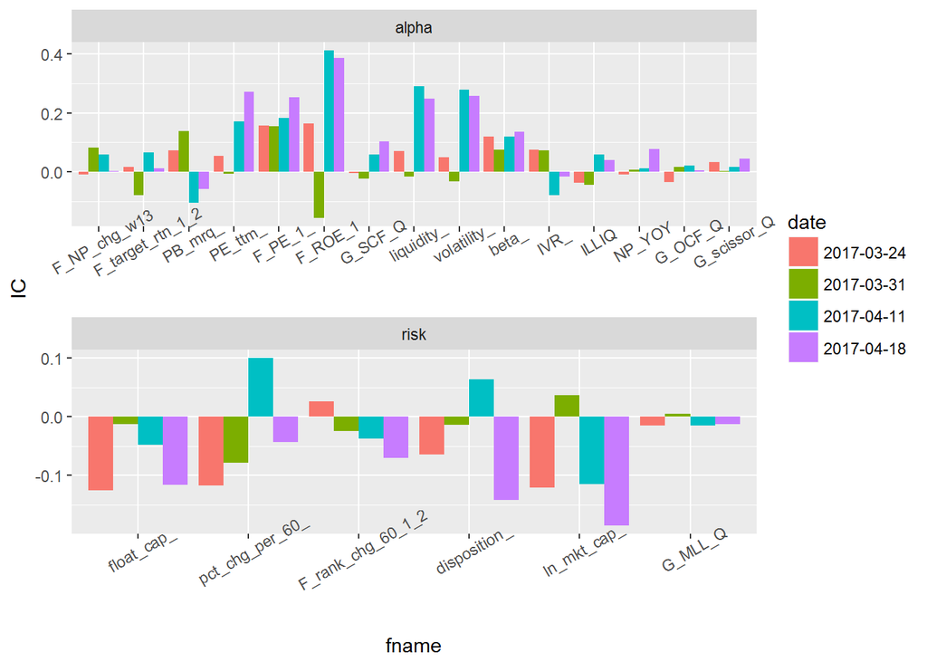

因子IC统计如下表所示。

| 因子名 | 全市场排名 | 全市场均值 | 全市场胜率 | 沪深300排名 | 沪深300均值 | 沪深300胜率 | 中证500排名 | 中证500均值 | 中证500胜率 |
| --- | --- | --- | --- | --- | --- | --- | --- | --- | --- |
| liquidity_ | 1 | 0.233 | 1.00 | 2 | 0.195 | 0.75 | 3 | 0.149 | 0.75 |
| volatility_ | 2 | 0.212 | 1.00 | 6 | 0.150 | 0.75 | 4 | 0.138 | 0.75 |
| F_PE_1_ | 3 | 0.212 | 1.00 | 4 | 0.165 | 1.00 | 2 | 0.186 | 1.00 |
| beta_ | 4 | 0.157 | 1.00 | 1 | 0.238 | 0.75 | 6 | 0.113 | 1.00 |
| PE_ttm_ | 5 | 0.152 | 1.00 | 3 | 0.167 | 1.00 | 5 | 0.123 | 0.75 |
| PB_mrq_ | 6 | 0.131 | 1.00 | 10 | 0.025 | 0.50 | 12 | 0.013 | 0.50 |
| F_ROE_1 | 7 | 0.127 | 0.75 | 5 | 0.160 | 0.75 | 1 | 0.201 | 0.75 |
| G_scissor_Q | 8 | 0.049 | 1.00 | 11 | 0.023 | 0.50 | 9 | 0.024 | 1.00 |
| F_NP_chg_w13 | 9 | 0.044 | 0.75 | 7 | 0.107 | 0.75 | 8 | 0.034 | 0.75 |
| NP_YOY | 10 | 0.042 | 1.00 | 8 | 0.052 | 0.75 | 10 | 0.022 | 0.75 |
| G_SCF_Q | 11 | 0.017 | 0.75 | 12 | 0.020 | 0.50 | 7 | 0.034 | 0.50 |
| F_rank_chg_60_1_2 | 12 | 0.011 | 0.75 | 13 | 0.007 | 0.25 | 17 | -0.026 | 0.25 |
| IVR_ | 13 | 0.004 | 0.50 | 18 | -0.097 | 0.00 | 11 | 0.014 | 0.50 |
| G_OCF_Q | 14 | -0.003 | 0.25 | 15 | -0.024 | 0.50 | 15 | 0.002 | 0.75 |
| G_MLL_Q | 15 | -0.010 | 0.50 | 14 | -0.004 | 0.25 | 16 | -0.009 | 0.25 |
| F_target_rtn_1_2 | 16 | -0.018 | 0.00 | 9 | 0.032 | 0.75 | 14 | 0.003 | 0.75 |
| disposition_ | 17 | -0.086 | 0.25 | 16 | -0.046 | 0.50 | 19 | -0.039 | 0.25 |
| pct_chg_per_60_ | 18 | -0.101 | 0.00 | 17 | -0.051 | 0.00 | 18 | -0.035 | 0.25 |
| ILLIQ | 19 | -0.133 | 0.00 | 19 | -0.098 | 0.25 | 13 | 0.004 | 0.50 |
| float_cap_ | 20 | -0.218 | 0.00 | 21 | -0.161 | 0.25 | 20 | -0.075 | 0.00 |
| ln_mkt_cap_ | 21 | -0.220 | 0.00 | 20 | -0.142 | 0.25 | 21 | -0.096 | 0.25 |

### (f2)近一个月周频因子分组超额收益

全市场，不同时间段，根据因子得分分为10组，得分最高的组**超额**收益率如下图所示，根据累计收益率大于0和区间收益率为正概率大于0.5,简单区分了alpha因子和风险因子。

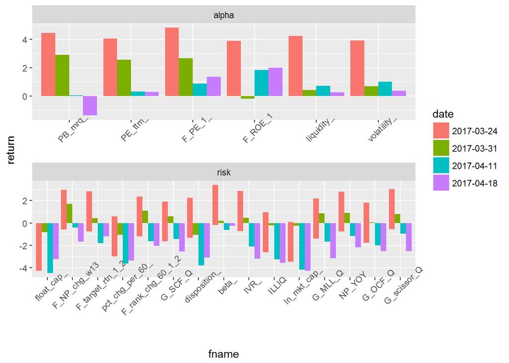

沪深300内得分最高的组**超额**收益率如下图所示。

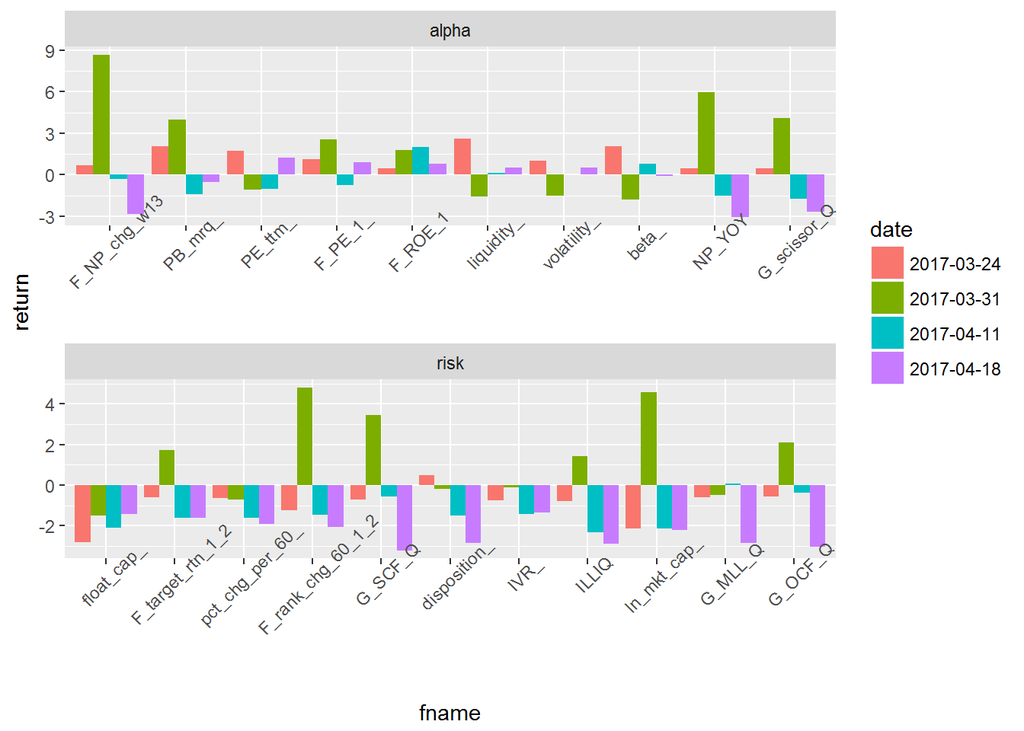

中证500内得分最高的组**超额**收益率如下图所示。

[figure not shown]

各个样本空间内，因子得分最高的一组和得分最低的一组的**超额**累积收益率统计如下表所示。

| 因子名 | 全市场Q1 | 全市场Q10 | 沪深300Q1 | 沪深300Q10 | 中证500Q1 | 中证500Q10 |
| --- | --- | --- | --- | --- | --- | --- |
| F_PE_1_ | 11.4 | -6.6 | 4.5 | -5.6 | 15.1 | -2.7 |
| F_ROE_1 | 8.1 | -1.5 | 5.2 | 0.3 | 10.5 | -5.1 |
| PE_ttm_ | 7.9 | -6.4 | 2.0 | -7.2 | 10.0 | -0.4 |
| PB_mrq_ | 7.0 | -8.5 | 5.8 | -2.7 | 8.4 | 2.1 |
| volatility_ | 6.5 | -12.5 | 0.5 | -5.7 | 5.1 | -3.4 |
| liquidity_ | 6.4 | -15.8 | 3.8 | -10.6 | 2.7 | -4.2 |
| beta_ | 2.5 | -10.6 | 2.6 | -13.0 | 8.1 | -2.1 |
| F_NP_chg_w13 | 1.9 | -2.3 | 6.2 | -4.7 | 2.3 | 0.1 |
| G_scissor_Q | -0.3 | -4.5 | 0.0 | -5.0 | 0.9 | 0.2 |
| NP_YOY | -0.5 | -4.8 | 1.7 | -3.8 | 1.0 | 0.5 |
| F_target_rtn_1_2 | -0.6 | -2.8 | -2.3 | -5.8 | 0.6 | -1.4 |
| F_rank_chg_60_1_2 | -1.5 | -2.5 | -0.9 | -3.1 | 3.1 | 4.4 |
| IVR_ | -2.8 | -5.0 | -3.9 | 1.4 | 4.1 | -0.8 |
| G_SCF_Q | -3.1 | -4.8 | -1.4 | -4.1 | 3.0 | 0.4 |
| G_MLL_Q | -3.3 | -2.6 | -4.1 | -1.5 | 0.9 | 2.0 |
| G_OCF_Q | -4.4 | -4.2 | -2.1 | -1.9 | 2.9 | 1.7 |
| disposition_ | -7.0 | 0.4 | -4.0 | -5.3 | -2.1 | 6.1 |
| ILLIQ | -8.5 | 4.5 | -4.9 | 1.8 | 1.0 | -0.4 |
| pct_chg_per_60_ | -10.1 | -0.3 | -5.0 | -7.1 | -2.5 | 2.3 |
| ln_mkt_cap_ | -11.6 | 7.9 | -3.7 | 1.7 | 1.3 | 5.2 |
| float_cap_ | -12.9 | 8.2 | -9.8 | 1.2 | -1.2 | 4.6 |

### (f3)近一年月频因子IC

全市场因子IC表现如下图所示。

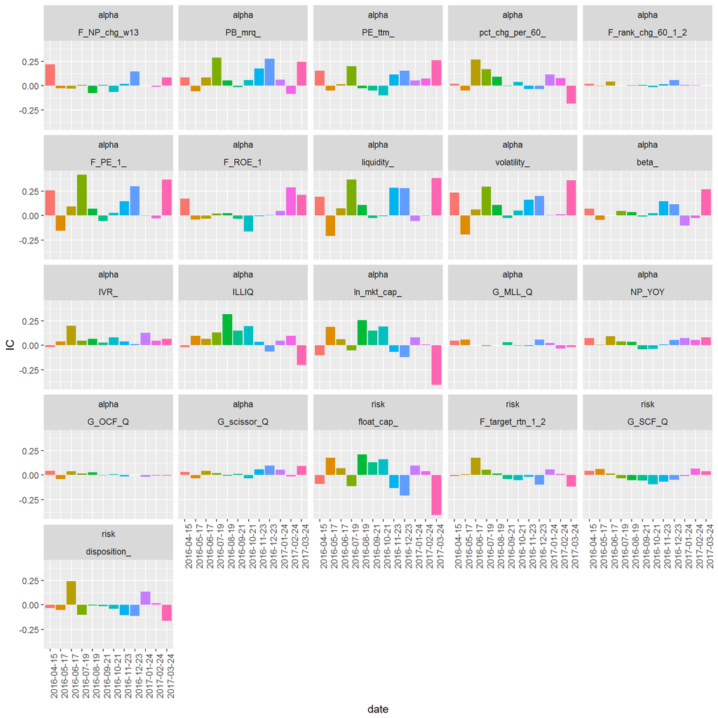

沪深300因子IC表现如下图所示。

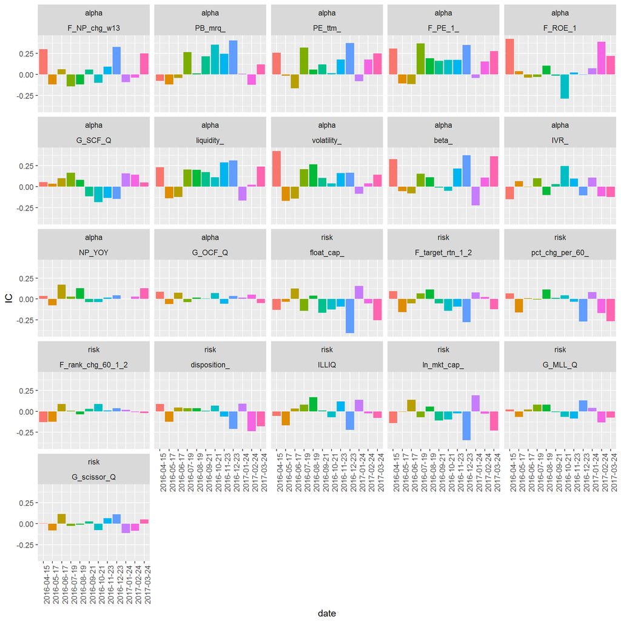

中证500因子IC表现如下图所示。

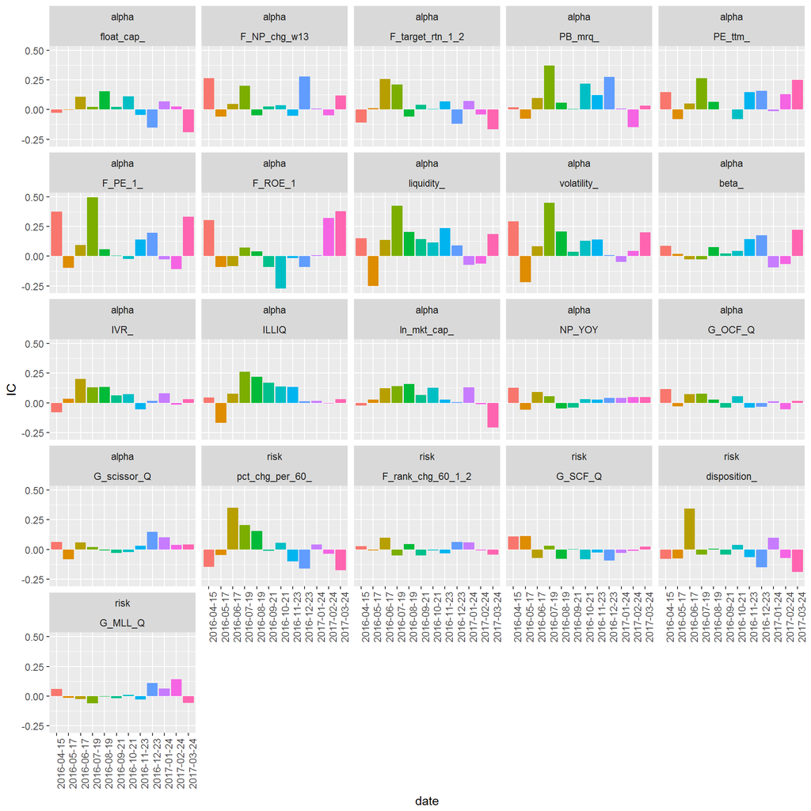

因子IC统计如下表所示。

|  | 因子名 | 全市场排名 | 全市场均值 | 全市场胜率 | 沪深300排名 | 沪深300均值 | 沪深300胜率 | 中证500排名 | 中证500均值 | 中证500胜率 |
| --- | --- | --- | --- | --- | --- | --- | --- | --- | --- | --- |
| 22 | F_PE_1_ | 1 | 0.119 | 0.67 | 1 | 0.158 | 0.75 | 1 | 0.121 | 0.67 |
| 23 | liquidity_ | 2 | 0.114 | 0.58 | 3 | 0.114 | 0.75 | 3 | 0.109 | 0.75 |
| 24 | volatility_ | 3 | 0.105 | 0.83 | 6 | 0.097 | 0.75 | 2 | 0.110 | 0.83 |
| 25 | PB_mrq_ | 4 | 0.097 | 0.75 | 4 | 0.106 | 0.67 | 5 | 0.082 | 0.83 |
| 26 | ILLIQ | 5 | 0.071 | 0.75 | 16 | -0.006 | 0.50 | 6 | 0.077 | 0.83 |
| 27 | PE_ttm_ | 6 | 0.066 | 0.67 | 2 | 0.125 | 0.75 | 4 | 0.087 | 0.75 |
| 28 | IVR_ | 7 | 0.061 | 0.92 | 12 | 0.006 | 0.50 | 8 | 0.051 | 0.75 |
| 29 | beta_ | 8 | 0.044 | 0.58 | 5 | 0.104 | 0.58 | 9 | 0.048 | 0.67 |
| 30 | F_ROE_1 | 9 | 0.040 | 0.58 | 7 | 0.075 | 0.58 | 11 | 0.040 | 0.50 |
| 31 | pct_chg_per_60_ | 10 | 0.039 | 0.58 | 19 | -0.047 | 0.50 | 17 | 0.011 | 0.42 |
| 32 | NP_YOY | 11 | 0.036 | 0.83 | 9 | 0.037 | 0.75 | 12 | 0.030 | 0.75 |
| 33 | G_scissor_Q | 12 | 0.028 | 0.67 | 13 | -0.002 | 0.50 | 13 | 0.030 | 0.67 |
| 34 | F_NP_chg_w13 | 13 | 0.023 | 0.58 | 8 | 0.040 | 0.50 | 7 | 0.064 | 0.67 |
| 35 | ln_mkt_cap_ | 14 | 0.016 | 0.58 | 20 | -0.056 | 0.25 | 10 | 0.047 | 0.75 |
| 36 | G_MLL_Q | 15 | 0.013 | 0.50 | 15 | -0.005 | 0.50 | 14 | 0.015 | 0.42 |
| 37 | F_rank_chg_60_1_2 | 16 | 0.012 | 0.83 | 14 | -0.004 | 0.58 | 19 | 0.007 | 0.42 |
| 38 | G_OCF_Q | 17 | 0.004 | 0.50 | 11 | 0.012 | 0.67 | 16 | 0.015 | 0.58 |
| 39 | F_target_rtn_1_2 | 18 | 0.000 | 0.50 | 18 | -0.043 | 0.42 | 15 | 0.015 | 0.58 |
| 40 | float_cap_ | 19 | -0.005 | 0.58 | 21 | -0.089 | 0.25 | 18 | 0.008 | 0.58 |
| 41 | G_SCF_Q | 20 | -0.011 | 0.42 | 10 | 0.018 | 0.67 | 20 | -0.010 | 0.42 |
| 42 | disposition_ | 21 | -0.019 | 0.25 | 17 | -0.037 | 0.58 | 21 | -0.019 | 0.33 |

### (f4)近一年月频因子分组超额收益

全市场，不同时间段，根据因子得分分为10组，得分最高的组**超额**收益率如下图所示，根据累计收益率大于0和区间收益率为正概率大于0.5,简单区分了alpha因子和风险因子。

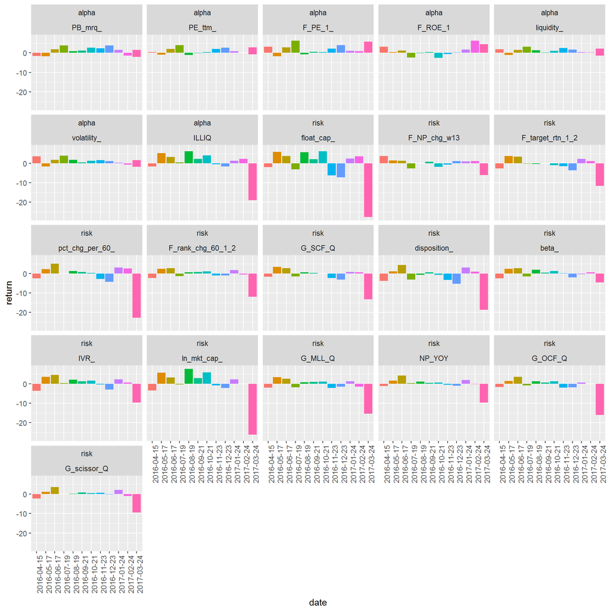

沪深300内得分最高的组**超额**收益率如下图所示。

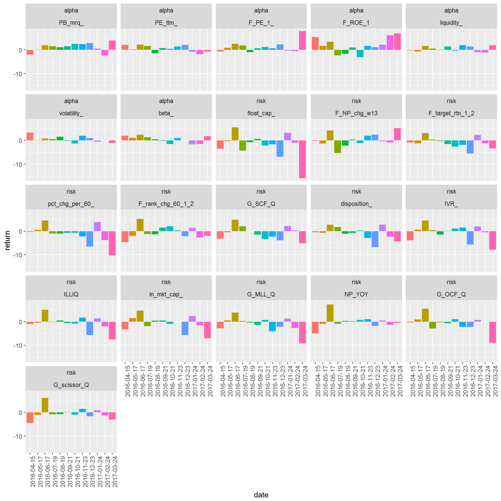

中证500内得分最高的组**超额**收益率如下图所示。

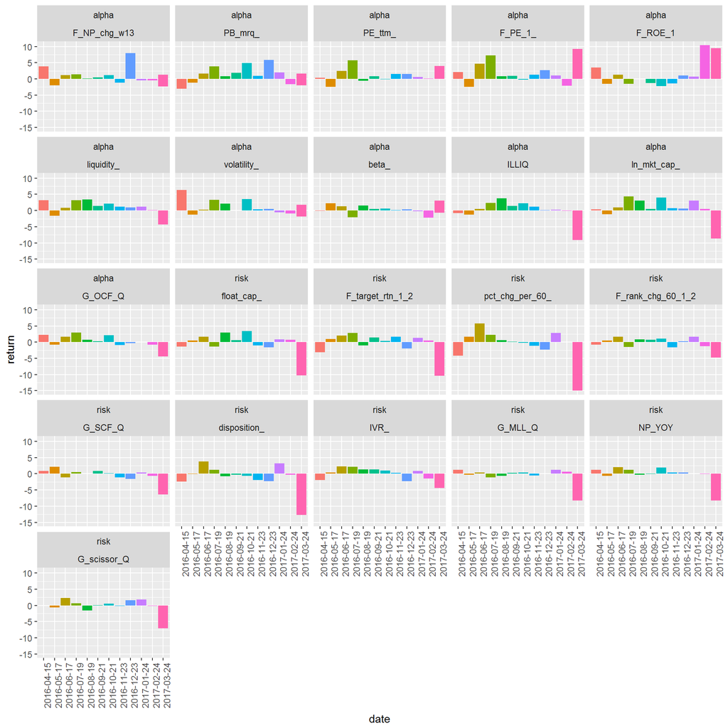

各个样本空间内，因子得分最高的一组和得分最低的一组的**超额**累积收益率统计如下表所示。

|  | 因子名 | 全市场Q1 | 全市场Q10 | 沪深300Q1 | 沪深300Q10 | 中证500Q1 | 中证500Q10 |
| --- | --- | --- | --- | --- | --- | --- | --- |
| 22 | F_PE_1_ | 27.5 | -29.7 | 17.0 | -19.7 | 28.2 | -17.8 |
| 23 | liquidity_ | 14.7 | -42.8 | 6.1 | -24.8 | 12.0 | -21.8 |
| 24 | PB_mrq_ | 13.6 | -30.7 | 15.6 | -22.6 | 16.5 | -14.2 |
| 25 | PE_ttm_ | 13.2 | -21.9 | 6.5 | -24.0 | 14.6 | -15.6 |
| 26 | volatility_ | 13.1 | -35.1 | 6.8 | -20.9 | 14.1 | -24.2 |
| 27 | F_ROE_1 | 12.9 | -14.4 | 24.8 | 1.4 | 19.1 | -8.3 |
| 28 | ILLIQ | 0.2 | -11.7 | -9.7 | 2.9 | 0.3 | -22.8 |
| 29 | IVR_ | -0.9 | -19.7 | -9.5 | -5.7 | -0.6 | -11.1 |
| 30 | F_NP_chg_w13 | -1.7 | -14.1 | 2.9 | -13.4 | 11.3 | -9.3 |
| 31 | beta_ | -2.0 | -30.3 | 5.6 | -32.3 | 4.5 | -21.9 |
| 32 | NP_YOY | -3.0 | -18.3 | -0.8 | -15.2 | -2.3 | -11.3 |
| 33 | G_scissor_Q | -4.4 | -15.8 | -6.2 | -11.7 | -2.9 | -11.1 |
| 34 | ln_mkt_cap_ | -7.9 | 4.4 | -10.7 | 10.8 | 8.2 | -1.4 |
| 35 | F_rank_chg_60_1_2 | -8.9 | -11.6 | -5.8 | -6.3 | -3.2 | -3.0 |
| 36 | F_target_rtn_1_2 | -11.2 | -10.4 | -11.7 | -3.8 | -5.6 | -8.1 |
| 37 | G_SCF_Q | -13.4 | -13.9 | -10.5 | -15.5 | -5.9 | -9.8 |
| 38 | G_OCF_Q | -13.5 | -14.7 | -9.6 | -10.5 | 2.8 | -5.4 |
| 39 | G_MLL_Q | -14.0 | -15.4 | -15.1 | -8.4 | -6.7 | -3.5 |
| 40 | pct_chg_per_60_ | -17.3 | -19.2 | -17.2 | -1.7 | -9.8 | -4.0 |
| 41 | float_cap_ | -18.6 | 5.4 | -24.5 | 13.9 | -5.2 | -1.0 |
| 42 | disposition_ | -23.6 | -6.6 | -11.8 | -3.3 | -13.0 | -1.7 |